# Прогнозирование заказов такси

Компании «Чётенькое такси» нужно спрогнозировать количество заказов такси на следующий час, чтобы привлекать больше водителей в период пиковой нагрузки. Для этого были собраны исторические данные о заказах такси в аэропортах. Построим модель для такого предсказания.

%pip install scikit-learn==1.2.0.

```python
import lightgbm as lgb
import numpy as np
import pandas as pd
import seaborn as sns

from catboost import CatBoostRegressor
from matplotlib import pyplot as plt

from sklearn.compose import make_column_transformer
from sklearn.linear_model import LinearRegression, Ridge
from sklearn.metrics import mean_squared_error
from sklearn.model_selection import train_test_split, RandomizedSearchCV, GridSearchCV, TimeSeriesSplit
from sklearn.pipeline import make_pipeline
from sklearn.preprocessing import StandardScaler, OneHotEncoder

from statsmodels.tsa.seasonal import seasonal_decompose

%matplotlib inline
```

## Загрузка и обработка данных

```python
try:
    df = pd.read_csv('/datasets/taxi.csv', index_col=[0], parse_dates=[0])
except:
    df = pd.read_csv('datasets/taxi.csv', index_col=[0], parse_dates=[0])
```

```python
df.head()
```

| datetime | num_orders |
| --- | --- |
| 2018-03-01 00:00:00 | 9 |
| 2018-03-01 00:10:00 | 14 |
| 2018-03-01 00:20:00 | 28 |
| 2018-03-01 00:30:00 | 20 |
| 2018-03-01 00:40:00 | 32 |

Как видим, данные собраны с интервалом в 10 минут.

Проверим, расположенны ли данные заказов в хронологическом порядке:

```python
df.index.is_monotonic_increasing
```

```
True
```

Т.к. необходимо будет предсказывать количество заказов на будущий час, то выполним ресемплирование по часу.

```python
df = df.resample('1H').sum()
```

```python
df.head()
```

| datetime | num_orders |
| --- | --- |
| 2018-03-01 00:00:00 | 124 |
| 2018-03-01 01:00:00 | 85 |
| 2018-03-01 02:00:00 | 71 |
| 2018-03-01 03:00:00 | 66 |
| 2018-03-01 04:00:00 | 43 |

## Анали данных

```python
df.index.max()
```

```
Timestamp('2018-08-31 23:00:00', freq='H')
```

```python
df.index.min()
```

```
Timestamp('2018-03-01 00:00:00', freq='H')
```

В нашем распоряжении данные за полгода, помсотрим на количество заказов в первую и последнюю неделю.

```python
df.index.min().dayofweek
```

```
3
```

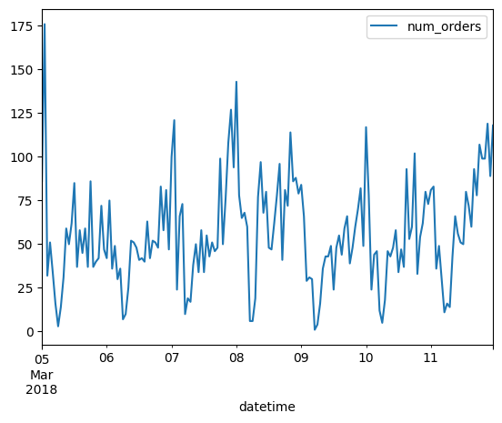

```python
df['2018-03-05':'2018-03-11'].plot();
```

На первой неделе больше всего заказов было в понедельник и в середине недели.

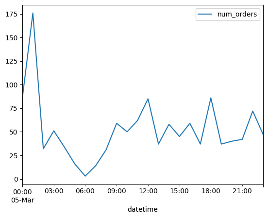

```python
df['2018-03-05':'2018-03-05'].plot();
```

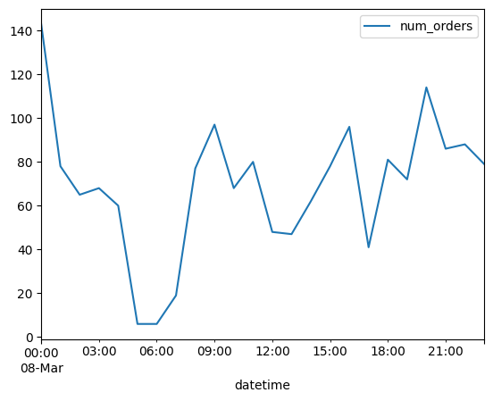

```python
df['2018-03-08':'2018-03-08'].plot();
```

Дневные графики на первой неделе показывают, что в ночное время заказов значительно больше.

```python
df.index.max().dayofweek
```

```
4
```

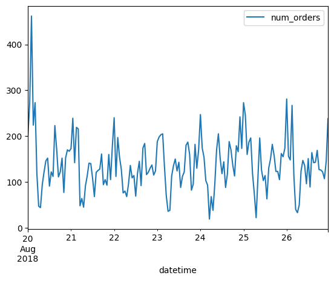

```python
df['2018-08-20':'2018-08-26'].plot();
```

На последней неделе также больше всего заказов было в понедельник.

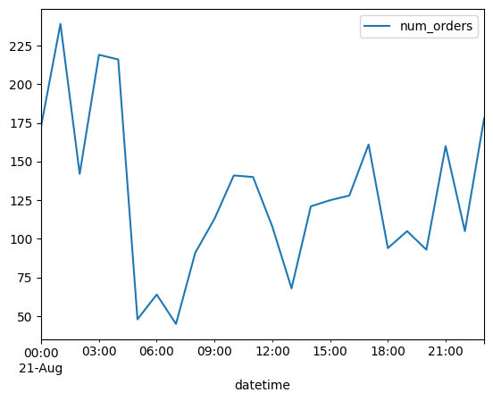

```python
df['2018-08-21':'2018-08-21'].plot();
```

На последней неделе также больше заказов в ночное время.

Разожим временной ряд на тренд и сезонную компоненту:

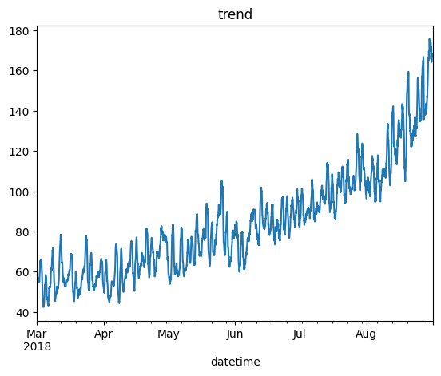

```python
decomposed = seasonal_decompose(df)
decomposed.trend.plot(title='trend');
```

Тренд показывает рост числа заказов за последние полгода в 3 раза.

Посмотрим на сезонную компоненту на примере первой недели:

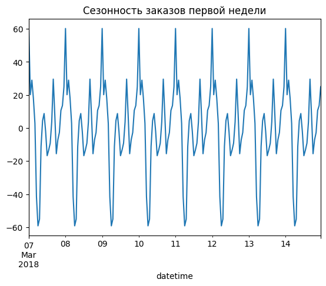

```python
decomposed.seasonal['2018-03-07':'2018-03-14'].plot(title='Сезонность заказов первой недели');
```

На графике видно, чёткая периодизация заказов в зависимости от времени суток.

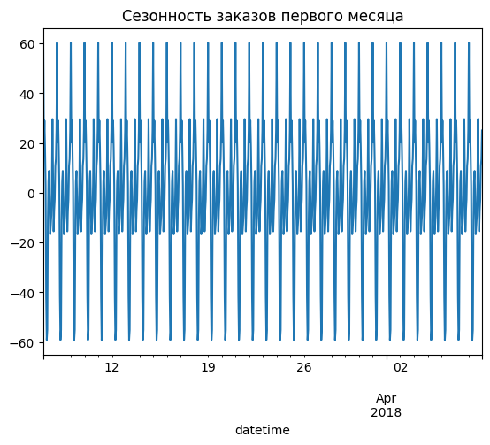

```python
decomposed.seasonal['2018-03-07':'2018-04-07'].plot(title='Сезонность заказов первого месяца');
```

Точно такая же периодизация наблюдается и в течение первого месяца.

Посмотрим также на компоненту шума:

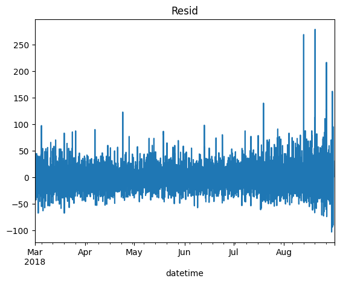

```python
decomposed.resid.plot(title='Resid');
```

В конце временного ряда наблюдается увеличение компоненты шума, что может негативно сказаться на качестве прогноза, т.к. тестовая выборка будет состоять из последних хронологических данных.

## Обучение моделей

Создадим функцию для добавления новых признаков и разбиения на обучающую и тестовую выборку:

```python
def make_features(data, max_lag, rolling_mean_size):
    # добавуляем новые признаки
    #data['year'] = data.index.year
    #data['month'] = data.index.month
    #data['day'] = data.index.day
    data['hour'] = data.index.hour
    data['dayofweek'] = data.index.dayofweek

    # добавляем предшествующие значения
    #for lag in range(24, 24 * max_lag + 1, 24):
        #data[f'lag_{lag}'] = data['num_orders'].shift(lag)
    data[f'lag_7'] = data['num_orders'].shift(24*7)

    # добавляем скользящее среднее
    data['rolling_mean'] = data['num_orders'].shift().rolling(rolling_mean_size).mean()
    data.dropna(inplace=True)

    # разделяем целевые признаки и параметры
    target = data['num_orders']
    features = data.drop('num_orders', axis=1)

    # меняем тип данных для некоторых признаков на категориальный
    for col in ['dayofweek', 'hour']:
        features[col] = features[col].astype('category')

    # возвращаем обучающую и тестовые выборки
    return train_test_split(features, target, shuffle=False, test_size=0.1)
    #return data
```

```python
features_train, features_test, target_train, target_test = make_features(df, 7, 24)
```

```python
for frame in [features_train, features_test, target_train, target_test]:
    print(frame.shape)
```

```
(3823, 4)
(425, 4)
(3823,)
(425,)
```

### Модель линейной регрессии

Обучим модель линейной регррессии.

```python
ohe_features = features_train.select_dtypes(include='category').columns.to_list()
ohe_features
```

```
['hour', 'dayofweek']
```

```python
num_features = features_train.select_dtypes(exclude='category').columns.to_list()
num_features
```

```
['lag_7', 'rolling_mean']
```

```python
scaler = StandardScaler().fit(features_train[num_features])
features_train[num_features] = scaler.transform(features_train[num_features])
features_test[num_features] = scaler.transform(features_test[num_features])
```

```python
features_train_ohe = OneHotEncoder().fit_transform(features_train[ohe_features])
features_test_ohe = OneHotEncoder().fit_transform(features_test[ohe_features])
```

```python
linear_model = LinearRegression().fit(features_train_ohe, target_train)
```

```python
linear_predictions = linear_model.predict(features_test_ohe)
```

```python
linear_score = mean_squared_error(target_test, linear_predictions) ** 0.5
linear_score
```

```
75.19036707278192
```

Модель линейной регрессии не может добиться качества метрики на целевом уровне.

### CatBoost

Обучим модель CatBoost и подберём для неё оптимальные гиперпараметры.

```python
features_train, features_test, target_train, target_test = make_features(df, 7, 24)
```

```python
cat_model = CatBoostRegressor(loss_function='RMSE',
                        silent=True,
                        cat_features=ohe_features)
```

```python
cat_params = {'iterations': [50, 100],
        'learning_rate': np.logspace(-3, -1, 5),
        'depth': [d for d in range(2, 11)],
        'l2_leaf_reg': np.logspace(-1, 1, 3)
             }

cat_grid = RandomizedSearchCV(cat_model,
                              cat_params,
                              cv=TimeSeriesSplit(),
                              scoring='neg_root_mean_squared_error',
                              n_iter=10

#cat_grid = GridSearchCV(
    #cat_model,
    #param_grid=cat_params,
    #scoring='neg_root_mean_squared_error',
    #n_jobs=-1,
    #verbose=False
)
```

```python
%%time
cat_grid.fit(features_train, target_train);
```

```
CPU times: user 25.9 s, sys: 6.92 s, total: 32.9 s
Wall time: 25.7 s
```

```
RandomizedSearchCV(cv=TimeSeriesSplit(gap=0, max_train_size=None, n_splits=5, test_size=None),
                   estimator=<catboost.core.CatBoostRegressor object at 0x7f03cc18eb50>,
                   param_distributions={'depth': [2, 3, 4, 5, 6, 7, 8, 9, 10],
                                        'iterations': [50, 100],
                                        'l2_leaf_reg': array([ 0.1,  1. , 10. ]),
                                        'learning_rate': array([0.001     , 0.00316228, 0.01      , 0.03162278, 0.1       ])},
                   scoring='neg_root_mean_squared_error')
```

Покажем важность влияния признаков на количество заказов.

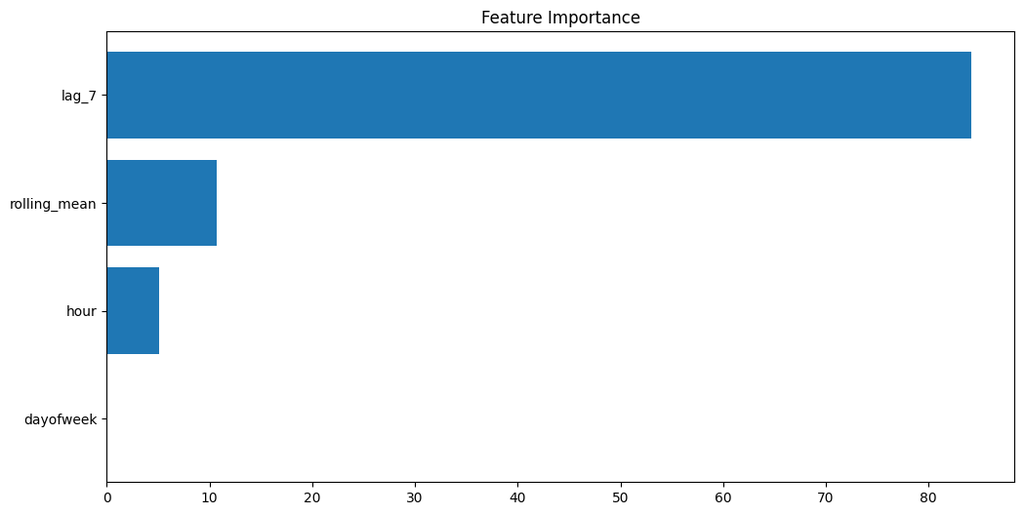

```python
cat_imp = cat_grid.best_estimator_.feature_importances_
sorted_idx = np.argsort(cat_imp)
fig = plt.figure(figsize=(12, 6))
plt.barh(range(len(sorted_idx)), cat_imp[sorted_idx], align='center')
plt.yticks(range(len(sorted_idx)), np.array(features_train.columns)[sorted_idx])
plt.title('Feature Importance');
```

Главным признаком, влияющим на прогноз является количество заказов в этот час неделю назад.

### Light GBM

Обучим модель Light GBM и подберём для неё оптимальные гиперпараметры.

```python
lgbm_model = lgb.LGBMRegressor(verbose=-1)

lgbm_params = {
    'num_leaves': [31, 41, 51],
    'min_child_samples': [5, 15],
    'max_depth': [10, 20],
    'learning_rate': np.logspace(-3, -1, 5),
    'reg_alpha': np.logspace(-4, -2, 2)
                                           }

lgbm_grid = RandomizedSearchCV(lgbm_model,
                               lgbm_params,
                               scoring='neg_root_mean_squared_error',
                               n_iter=10,
                               verbose=False
#lgbm_grid = GridSearchCV(
    #lgbm_model,
    #param_grid=lgbm_params,
    #cv=TimeSeriesSplit(),
    #scoring='neg_root_mean_squared_error',
    #n_jobs=-1,
    #verbose=False
)
```

```python
%%time

lgbm_grid.fit(X=features_train, y=target_train)
```

```
CPU times: user 23.7 s, sys: 417 ms, total: 24.2 s
Wall time: 7.93 s
```

```
RandomizedSearchCV(estimator=LGBMRegressor(verbose=-1),
                   param_distributions={'learning_rate': array([0.001     , 0.00316228, 0.01      , 0.03162278, 0.1       ]),
                                        'max_depth': [10, 20],
                                        'min_child_samples': [5, 15],
                                        'num_leaves': [31, 41, 51],
                                        'reg_alpha': array([0.0001, 0.01  ])},
                   scoring='neg_root_mean_squared_error', verbose=False)
```

Оценим важность влияние признаков на количество заказов.

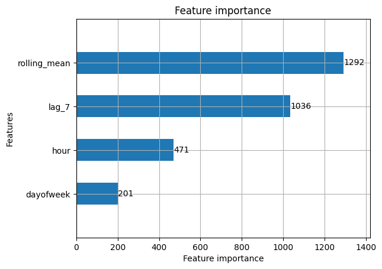

```python
lgb.plot_importance(lgbm_grid.best_estimator_, height=.5);
```

```python
grids = [
    #ridge_grid,
    lgbm_grid, cat_grid]
models_data = []
for grid in grids:
    # id модели с лучшими параметрами
    best_id = np.argmin(grid.cv_results_['rank_test_score'])
    models_data.append(
        [
            # лучшее значение метрики RMSE на обучающей выборке
            (-grid.cv_results_['mean_test_score'][best_id]).round(3),
            # время обучения модели
            grid.cv_results_['mean_fit_time'][best_id].round(3),
            # время плучения предсказаний
            grid.cv_results_['mean_score_time'][best_id].round(3)
        ]
    )
models_df = pd.DataFrame(data=models_data,
                         index=[#'Ridge',
                             'LightGBM', 'CatBoost'],
                         columns=['лучшее RMSE на обучающей выборке', 'время обучения модели', 'время получения предсказаний']
                        )
display(models_df)
```

|  | лучшее RMSE на обучающей выборке | время обучения модели | время получения предсказаний |
| --- | --- | --- | --- |
| LightGBM | 22.301 | 0.108 | 0.007 |
| CatBoost | 27.230 | 0.322 | 0.002 |

Посмотрим на среднеквадратичную ошибку прогнозов модели на тестовой выборке.

```python
(mean_squared_error(target_test, cat_grid.best_estimator_.predict(features_test)) ** 0.5).round(1)
```

```
55.6
```

Покажем ошибки моделе на примере прогнозов за несколько дней из тестовой выборки.

```python
def compare_target_predict(features_test, target_test, model, some_day):
    features_day = features_test[some_day:some_day]
    target_day = target_test[some_day:some_day].values
    predictions_day = model.predict(features_day)
    errors_day = predictions_day - target_day
    hours_day = features_day.index

    df_compare = pd.concat([pd.Series(hours_day), pd.Series(target_day), pd.Series(predictions_day), pd.Series(errors_day)], axis=1)
    df_compare.columns = ['hours', 'Реальное значение', 'Прогноз', 'Ошибка']
    df_compare = df_compare.set_index('hours')

    df_compare.plot(title=f'Сравнение прогноза модели с реальным значением за {some_day}', figsize=(10, 8), grid=True)

    plt.show()
```

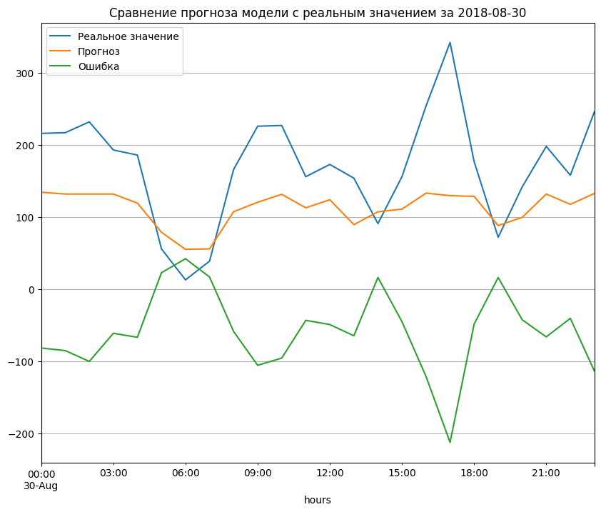

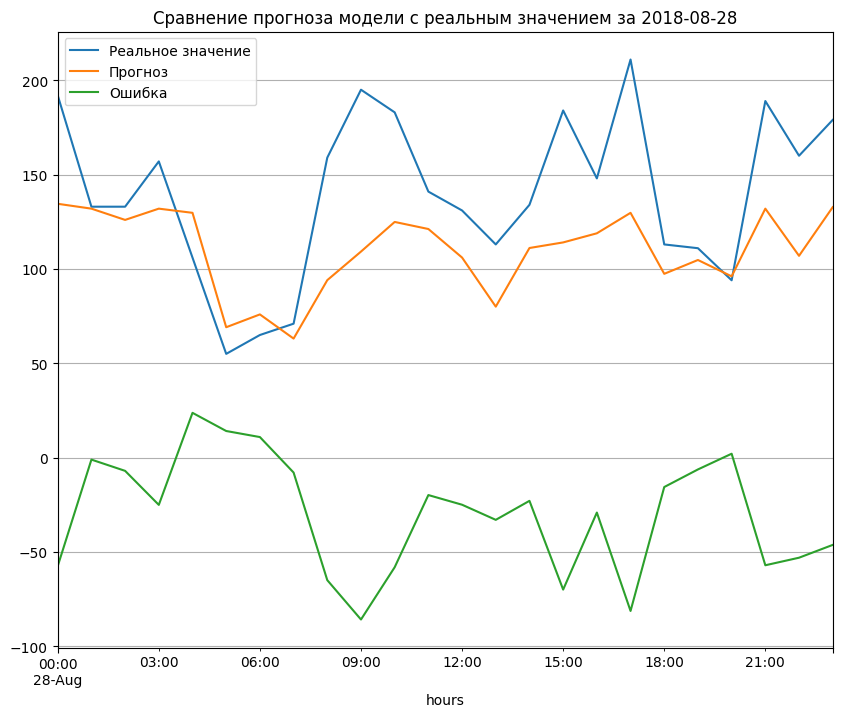

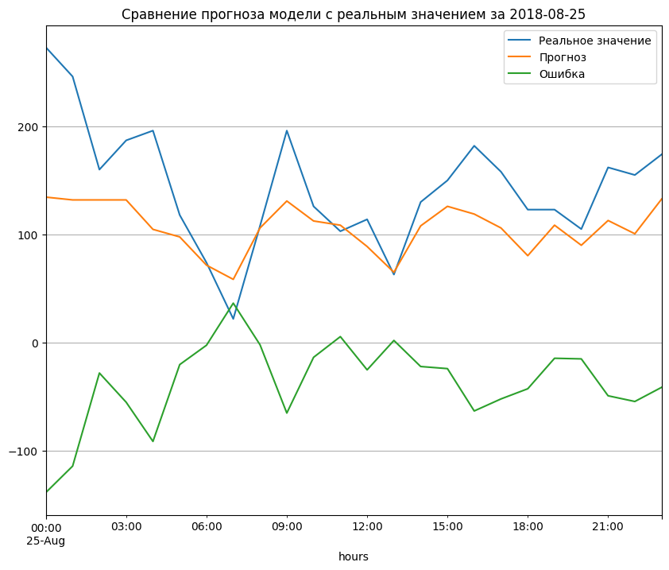

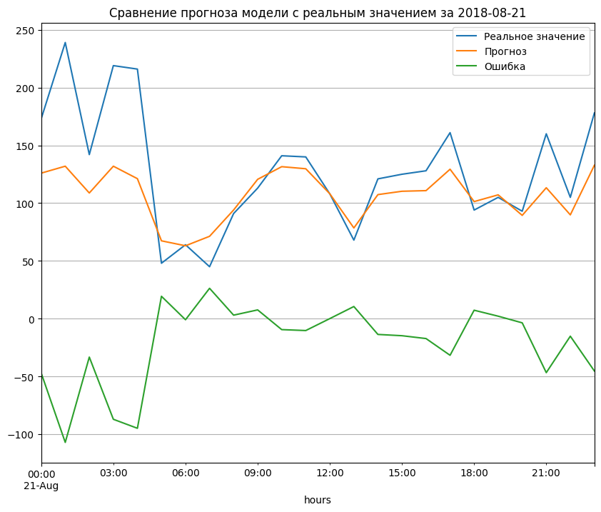

```python
for some_day in ['2018-08-30', '2018-08-28', '2018-08-25', '2018-08-21']:
    compare_target_predict(features_test, target_test, cat_grid.best_estimator_, some_day)
```

На графике видно, что модель даёт хороший прогноз в случаях, когда реальные значения заказов близки к средним, когда заказов мало(утром) модель завышает прогноз, когда много(ночью и вечером) - занижает.